# Práctica No. 3

Equipo 1

2022-04-26

# Ejercicio 3.1 Descomposición Clasica

El archivo `cavsales2.csv` representa las ventas mensuales de Cavanaugh Company desde enero de 2001 hasta diciembre de 2006.

## 1

Realice un análisis exploratorio de la serie y redacte un escrito de sus hallazgos. ( 1.5 PUNTOS)

```r
sales_data <- read_csv("cavsales.csv") # Se importan los datos
Ventas <- ts(sales_data$y,frequency=12,start=2001) # Se crea objeto de tipo ts()
```

### Análisis Exploratorio

#### Componente de tendencia

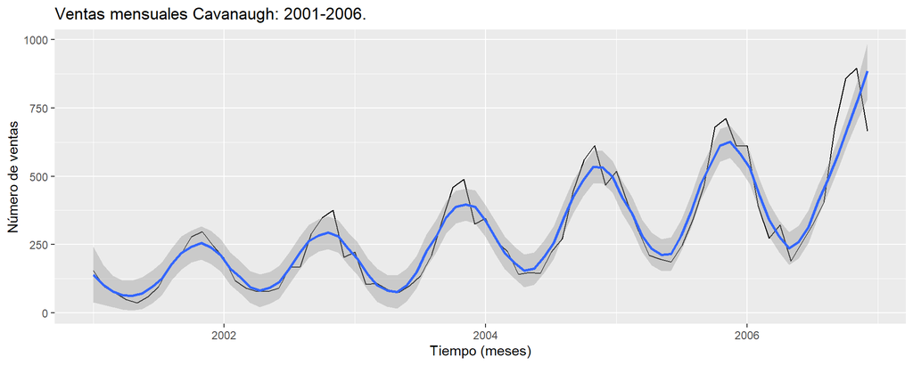

```r
autoplot(Ventas) + geom_smooth(method = "loess", span=0.2) + ggtitle("Ventas mensuales Cavanaugh: 2001-2006.") + xlab("Tiempo (meses)") + ylab("Número de ventas")
```

> Se tiene una serie mensual (periodo estacional $s=12$); Se observa tendencia; no se observan valores atípicos; no se observa componente horizontal; se observa un patrón estacional, además la amplitud de la variación estacional amenta conforme el tiempo amenta.

#### Componente estacional

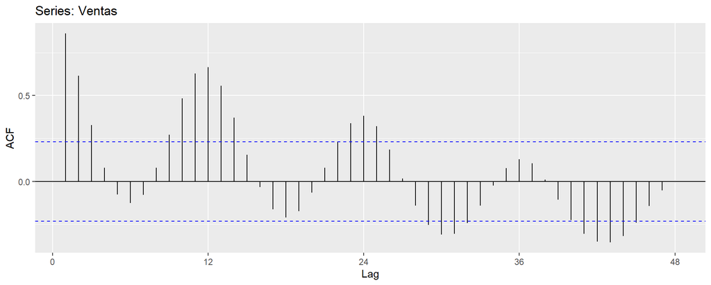

```r
ggAcf(Ventas, lag.max = 48)
```

> El Correlograma de la serie de tiempo nos muestra la relación lineal que tiene la serie con su pasado remoto, de esta manera podemos decir que la serie de tiempo presenta correlación serial. Además se puede ver que la correlación aumenta en los multiplos del periodo estacional, donde esa correlación va disminuyendo gradualmente conforme el número de rezagos aumenta.

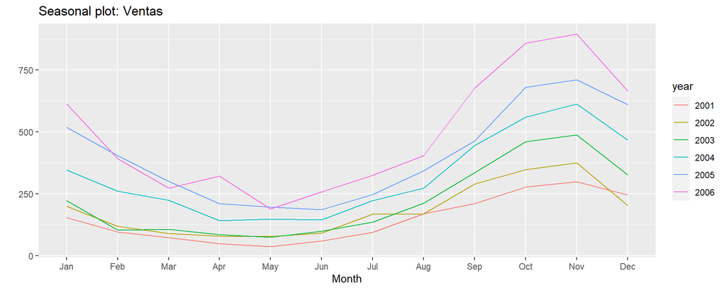

```r
ggseasonplot(Ventas)
```

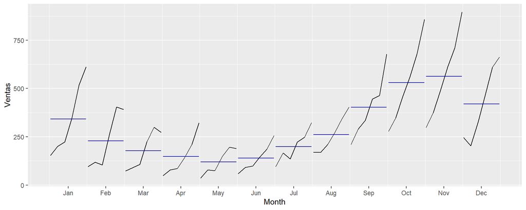

```r
ggsubseriesplot(Ventas)
```

> En esta gráfica se puede observar un poco más claro el comportamiento estacional de la serie, en donde la linea azul es el valor promedio de las ventas mesuales para cada periodo estacional, en las cuales se pude notar que su valor aumenta para los ultimos meses del año. Las ventas mensuales alcanza su mayor nivel en mes de noviembre para todos los años, mientras que para el mes de mayo se tiene su mayor caida.

## 2

Genere pronósticos para los primeros 5 meses de 2007 mediante una descomposición multiplicativa e interprete los índices estacionales. Graficar la serie de tiempo, los datos ajustados estacionalmene y el componente de tendencia. (2.0 PUNTOS)

> La variación estacional es dependiente de la tendencia, por lo que se opta por una descomposición multiplicativa.

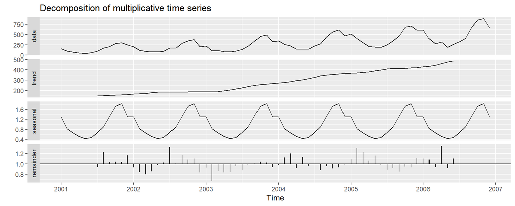

```r
dcm <- decompose(Ventas, type="mult")
autoplot(dcm)
```

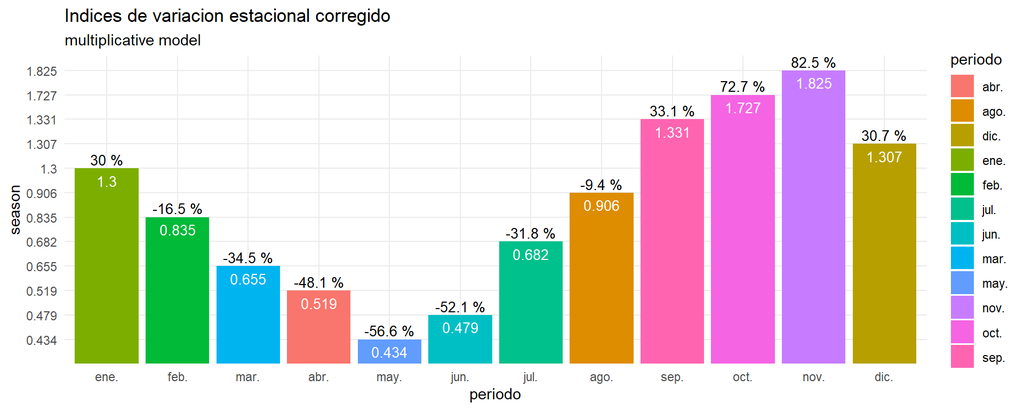

```r
index_plot(dcm)
```

> Se observa que para el mes de noviembre las ventas mensuales presentan su mayor incremento, un 82.5% respecto del promedio anual, mientras que para el mes de mayo presenta su mayor caida en cerca de 56.6% respecto del promedio anual.

### Desestacionalización

```r
yaj <- dcm$x/dcm$seasonal # Desestacionalización: modelo multiplicativo
trend <- dcm$trend  #Tendencia
```

#### Generar pronosticos desestacionalizados

```r
fc_adj <- holt(yaj, h=5) #se usa metodo de holt justo porque se tiene una tendencia lineal
all <- cbind('Observados'= yaj, "lower"=fc_adj$lower[,2],'fitted'= fc_adj$mean, "upper"=fc_adj$upper[,2])
dygraph(all,main = "Ventas Mensuales Cavanaugh Company", ylab = "Ventas", xlab = "Tiempo") %>%
  dyAxis("x", drawGrid = FALSE) %>% dyAxis("y", drawGrid = FALSE) %>%
  dySeries("Observados", color = "black") %>%
  dySeries(c("lower", "fitted","upper"), label = "Holt MP", color="red")  %>%
  dyHighlight(highlightCircleSize = 5, highlightSeriesBackgroundAlpha = 0.2) %>%
  dyLegend(width = 400) %>%
  dyRangeSelector(height = 20)
```

[interactive chart not shown]

#### Pronosticos reestacionalizados

```r
#Aquí se multiplica por la variacion estacional para que los pronosticos se ajusten al componente estacional
fc <- (fc_adj$mean)*(dcm$figure[1:5])
all2 <- cbind('Observados'= Ventas,'Pronosticos'= fc)
dygraph(all2,main = "Ventas Mensuales Cavanaugh Company", ylab = "Ventas", xlab = "Tiempo") %>%
  dyAxis("x", drawGrid = FALSE) %>% dyAxis("y", drawGrid = FALSE) %>%
  dySeries("Observados", color = "black") %>%
  dySeries("Pronosticos", color = "red") %>%
  dyHighlight(highlightCircleSize = 5, highlightSeriesBackgroundAlpha = 0.2) %>%
  dyLegend(width = 400) %>%
  dyRangeSelector(height = 20)
```

[interactive chart not shown]

```r
all3 <- cbind('Data'=Ventas,'Tendencia'= trend,'Seas_Adj'= yaj,'fitted'= fc_adj$mean, 'Pronosticos'= fc)
  dygraph(all3, main = "Ventas Mensuales Cavanaugh Company", ylab = "Ventas", xlab = "Tiempo") %>%
  dyAxis("x", drawGrid = FALSE) %>% dyAxis("y", drawGrid = FALSE) %>%
  dySeries("Data", color = "black") %>%
  dySeries("Tendencia", color = "green") %>%
  dySeries("Seas_Adj", color="blue")  %>%
  dySeries("fitted", label = "Holt MP", color="#28E2E5")  %>%
  dySeries("Pronosticos", color = "red") %>%
  dyHighlight(highlightCircleSize = 5, highlightSeriesBackgroundAlpha = 0.2) %>%
  dyLegend(width = 400) %>%
  dyRangeSelector(height = 20)
```

[interactive chart not shown]

## 3

El componente irregular (resto) de la descomposición multiplicativo es ruido blanco? Use el siguiente comando `Box.test(dcm$random, lag=24, type="Ljung-Box")` (1.5 PUNTOS)

### Análisis residual

#### Prueba de no correlación (*Ljung-Box test*)

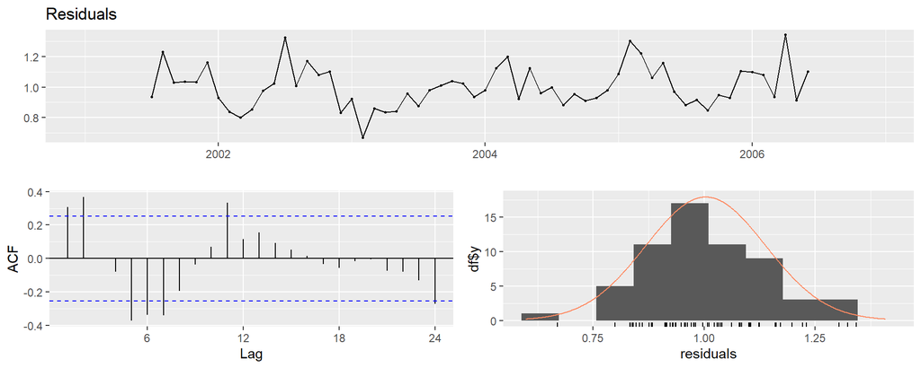

```r
res <- dcm$random
checkresiduals(res, test=F)
```

```r
(ljb_test <- Box.test(dcm$random, lag=24, type="Ljung-Box"))
```

```
    Box-Ljung test

data:  dcm$random
X-squared = 66.318, df = 24, p-value = 7.784e-06
```

> Ya que **Valor p=** 7.7838088^{-6}< 0.05, se rechaza $H_{0}$. Se encontro evidencia suficiente que justifica el rechazo de que los residuos son ruido blanco. Esto quiere decir el pronóstico del remanente no es cero y que hay información relevante que debe considerarse para mejorar los pronosticos.

## 4

Los pronósticos para los primeros 5 meses de 2007 fueron 628, 308, 324, 248 y 272, respectivamente. Compare sus pronósticos con los valores reales. (1.0 PUNTOS)

```r
reales <- c(628, 308, 324, 248, 272)
reales2 <- c(rep(NA,72),reales)

all4 <- cbind('Observados'=Ventas,'Descomposición clásica'= fc,'Datos Reales'=reales2)
  dygraph(all4, main = "Ventas Mensuales Cavanaugh Company", ylab = "Ventas", xlab = "Tiempo") %>%
  dyAxis("x", drawGrid = FALSE) %>% dyAxis("y", drawGrid = FALSE) %>%
  dySeries("Observados", color = "black") %>%
  dySeries("Descomposición clásica", color = "red") %>%
  dySeries("Datos Reales", color="blue")  %>%
  dyHighlight(highlightCircleSize = 5, highlightSeriesBackgroundAlpha = 0.2) %>%
  dyLegend(width = 400) %>%
  dyRangeSelector(height = 20)
```

[interactive chart not shown]

```r
tabla <- matrix(c(reales, fc), ncol = 5, byrow = T)
colnames(tabla) <- c("Jan","Feb","Mar","Apr","May")
rownames(tabla) <- c("Datos reales" ,"Descomposición Clasica M")
tabla %>% knitr::kable(digits=2)
```

|  | Jan | Feb | Mar | Apr | May |
| --- | --- | --- | --- | --- | --- |
| Datos reales | 628.00 | 308.00 | 324.00 | 248.00 | 272.00 |
| Descomposición Clasica M | 665.26 | 431.87 | 342.44 | 274.41 | 231.55 |

> Los pronosticos se ajustan adecuadamente al comportamiento real de los datos pero se podrian hallar mejores pronosticos

```r
accu2 <- accuracy(fc,reales) %>% round(2)
knitr::kable(accuracy(fc,reales), caption = "Datos reales vs Descomposición Clásica",digits=2)
```

Datos reales vs Descomposición Clásica

|  | ME | RMSE | MAE | MPE | MAPE |
| --- | --- | --- | --- | --- | --- |
| Test set | -33.11 | 62.3 | 49.29 | -9.52 | 15.47 |

> El `MAE` nos indica que los valores ajustados con este método tiene un promedio de error de 49.29. Podría parecer que este método es infructuoso, pero si observamos la gráfica de valores ajustados y observados, trabaja bien dentro de la muestra. Ese valor puede ser debido a la escala de la variable Ingresos.

> El `MAPE` indica el error como un porcentaje promedio del valor real que se va ajustar. El error promedio relativo al valor real observado de ventas es de 15.47%. En promedio los pronósticos generados con este método van a tener una desviación del 15.47% respecto del valor verdadero.

## 5

Use alguno de los siguientes métodos de descomposición de series de tiempo,

• Descomposición STL: `stl()` para la estimación de componentes latentes y `forecast()` para generar pronósticos.

• Descomposición con variables dummy: `tslm()` del paquete forecast

para generar pronósticos de los primeros 5 meses de 2007. Verifique si el componente irregular (resto) es ruido blanco.(2.5 PUNTOS)

### Descomposición STL (Descomposición por regresión local)

```r
l <- BoxCox.lambda(Ventas)
fit_stl <- BoxCox(Ventas, lambda = l)
```

> Dado que la descomposición por regresión local únicamente funciona para series de tiempo con estacionalidad aditiva, aplicamos la tranformación de Box Cox.

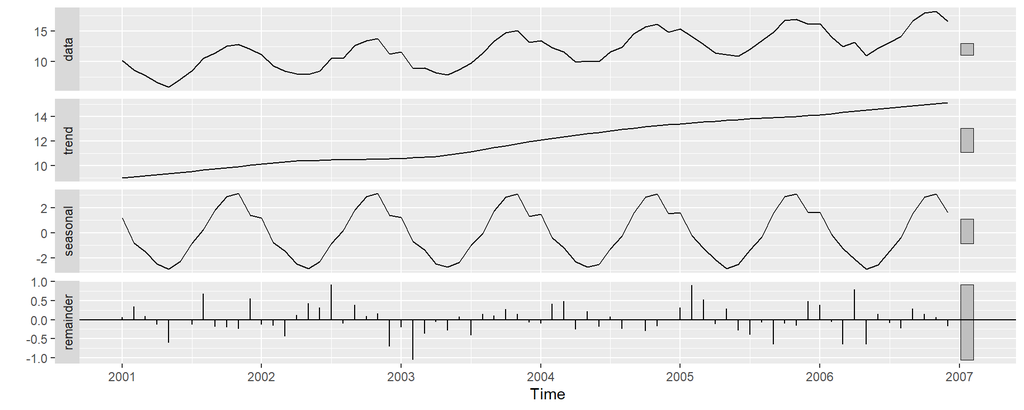

```r
fit <- stl(fit_stl, s.window=7, robust=FALSE)
autoplot(fit)
```

> En esta grafica se muestra la descomposicion de la serie de tiempo para cada uno de sus componentes latentes, tomando en concideracion que tanto el componente de tendencia como el de estacionalidad cambia un poco con forme pasa el tiempo.

#### Generar pronosticos desestacionalizados

```r
fc_adj <- fit %>% seasadj() %>% rwf(h=5, drift = T)

all <- cbind('Observados'= seasadj(fit), "lower"=fc_adj$lower[,2],'fitted'= fc_adj$mean, "upper"=fc_adj$upper[,2])
dygraph(all,main = "Ventas Mensuales Cavanaugh Company", ylab = "Ventas", xlab = "Tiempo") %>%
  dyAxis("x", drawGrid = FALSE) %>% dyAxis("y", drawGrid = FALSE) %>%
  dySeries("Observados", color = "black") %>%
  dySeries(c("lower", "fitted","upper"), label = "Rwdrift", color="red")  %>%
  dyHighlight(highlightCircleSize = 5, highlightSeriesBackgroundAlpha = 0.2) %>%
  dyLegend(width = 400) %>%
  dyRangeSelector(height = 20)
```

[interactive chart not shown]

> En esta grafica se muestran los pronosticos(metodo informal con drift) desestacionalizados a traves del metodo Stl

#### Pronosticos reestacionalizados

```r
fc_fit <- fit %>% forecast(method="rwdrift", h= 5)

all <- cbind('Observados'= fit_stl, "lower"=fc_fit$lower[,2],'fitted'= fc_fit$mean, "upper"=fc_fit$upper[,2])
dygraph(all,main = "Ventas Mensuales Cavanaugh Company", ylab = "Ventas", xlab = "Tiempo") %>%
  dyAxis("x", drawGrid = FALSE) %>% dyAxis("y", drawGrid = FALSE) %>%
  dySeries("Observados", color = "black") %>%
  dySeries(c("lower", "fitted","upper"), label = "Stl-rwdrift", color="red")  %>%
  dyHighlight(highlightCircleSize = 5, highlightSeriesBackgroundAlpha = 0.2) %>%
  dyLegend(width = 400) %>%
  dyRangeSelector(height = 20)
```

[interactive chart not shown]

```r
all4 <- cbind('Data'=fit_stl,'Tendencia'= trendcycle(fit),'Desestacionalizados'= seasadj(fit),'Pronosticos Desestacionalizados'= fc_adj$mean, 'Pronosticos estacionalizados'= fc_fit$mean)
  dygraph(all4, main = "Ventas Mensuales Cavanaugh Company", ylab = "Ventas", xlab = "Tiempo") %>%
  dyAxis("x", drawGrid = FALSE) %>% dyAxis("y", drawGrid = FALSE) %>%
  dySeries("Data", color = "black") %>%
  dySeries("Tendencia", color = "green") %>%
  dySeries("Desestacionalizados", color="blue")  %>%
  dySeries("Pronosticos Desestacionalizados", color="#28E2E5")  %>%
  dySeries("Pronosticos estacionalizados", color = "red") %>%
  dyHighlight(highlightCircleSize = 5, highlightSeriesBackgroundAlpha = 0.2) %>%
  dyLegend(width = 400) %>%
  dyRangeSelector(height = 20)
```

[interactive chart not shown]

> Se utilizo el método de rwdrift (método informal con drift) para realizar los pronósticos de los datos reestacionalizados a traves del metodo Stl

#### Prueba de no correlación (*Ljung-Box test*)

```r
ljb_test2 <- checkresiduals(fc_fit)
```

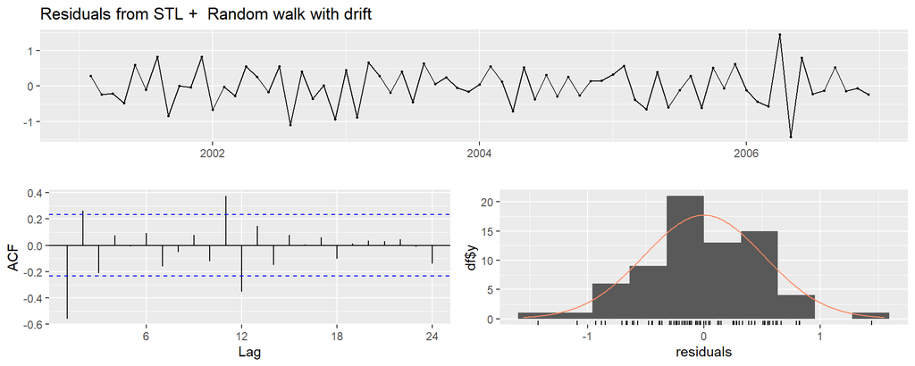

```
    Ljung-Box test

data:  Residuals from STL +  Random walk with drift
Q* = 64.048, df = 13, p-value = 9.813e-09

Model df: 1.   Total lags used: 14
```

> Ya que **Valor p=** 9.8127626^{-9}< 0.05, se rechaza $H_{0}$. Se encontro evidencia suficiente que justifica el rechazo de que los residuos son ruido blanco. Esto quiere decir el pronóstico del remanente no es cero y que hay información relevante que debe considerarse para mejorar los pronosticos.

## 6

Redacte brevemente un escrito en el que compare los resultados con descomposición clásica y el método seleccionado en el inciso anterior. (1.5 PUNTOS)

```r
reales <- c(628, 308, 324, 248, 272)
reales2 <- c(rep(NA,72),reales)
fcs <- InvBoxCox(fc_fit$mean, lambda = l)
all5 <- cbind('Observados'=Ventas,'Descomposición clásica'= fc,'Datos Reales'=reales2,'Descomposición Stl'=fcs )
  dygraph(all5, main = "Ventas Mensuales Cavanaugh Company", ylab = "Ventas", xlab = "Tiempo") %>%
  dyAxis("x", drawGrid = FALSE) %>% dyAxis("y", drawGrid = FALSE) %>%
  dySeries("Observados", color = "black") %>%
  dySeries("Descomposición clásica", color = "red") %>%
  dySeries("Datos Reales", color="blue")  %>%
  dySeries("Descomposición Stl", color="green")  %>%
  dyHighlight(highlightCircleSize = 5, highlightSeriesBackgroundAlpha = 0.2) %>%
  dyLegend(width = 400) %>%
  dyRangeSelector(height = 20)
```

[interactive chart not shown]

```r
fcs <- InvBoxCox(fc_fit$mean, lambda = l)
reales <- c(628, 308, 324, 248, 272)
tabla <- matrix(c(reales, fc,fcs), ncol = 5, byrow = T)
colnames(tabla) <- c("Jan","Feb","Mar","Apr","May")
rownames(tabla) <- c("Datos reales" ,"Descomposición Clasica M", "Descomposición STL")
tabla %>% knitr::kable(digits=2)
```

|  | Jan | Feb | Mar | Apr | May |
| --- | --- | --- | --- | --- | --- |
| Datos reales | 628.00 | 308.00 | 324.00 | 248.00 | 272.00 |
| Descomposición Clasica M | 665.26 | 431.87 | 342.44 | 274.41 | 231.55 |
| Descomposición STL | 678.23 | 481.68 | 388.31 | 328.53 | 276.56 |